# p8105_hw2_rm3609.Rmd

Runqi Ma

2018/10/4

# Set up

```r
library(tidyverse)
```

# Problem 1

### Read and clean the data; retain line, station, name, station latitude / longitude, routes served, entry, vending, entrance type, and ADA compliance.

### Convert the entry variable from character (YES vs NO) to a logical variable .

```r
ny_subway =
  read_csv(file = "./data/NYC_Transit_Subway_Entrance_And_Exit_Data.csv") %>%
  janitor::clean_names() %>%
  select(line:entry, vending, ada) %>%
  mutate(entry = recode(entry, "YES" = TRUE, "NO" = FALSE))
ny_subway
```

```
## # A tibble: 1,868 x 19
##    line  station_name station_latitude station_longitu… route1 route2
##    <chr> <chr>                   <dbl>            <dbl> <chr>  <chr>
##  1 4 Av… 25th St                  40.7            -74.0 R      <NA>
##  2 4 Av… 25th St                  40.7            -74.0 R      <NA>
##  3 4 Av… 36th St                  40.7            -74.0 N      R
##  4 4 Av… 36th St                  40.7            -74.0 N      R
##  5 4 Av… 36th St                  40.7            -74.0 N      R
##  6 4 Av… 45th St                  40.6            -74.0 R      <NA>
##  7 4 Av… 45th St                  40.6            -74.0 R      <NA>
##  8 4 Av… 45th St                  40.6            -74.0 R      <NA>
##  9 4 Av… 45th St                  40.6            -74.0 R      <NA>
## 10 4 Av… 53rd St                  40.6            -74.0 R      <NA>
## # ... with 1,858 more rows, and 13 more variables: route3 <chr>,
## #   route4 <chr>, route5 <chr>, route6 <chr>, route7 <chr>, route8 <int>,
## #   route9 <int>, route10 <int>, route11 <int>, entrance_type <chr>,
## #   entry <lgl>, vending <chr>, ada <lgl>
```

The dataset contains line, station name, station latitude and longitude, routes served, entry, vending, entrance type, and ADA compliance.

I have cleaned the variable names, selected the variables that I want, and changed the entry variable from character to a logical variable.

The resulting dataset is 1868 x 19.

The data is not tidy yet. Some column names contain variable.

### How many distinct stations are there?

```r
dist_both = distinct(ny_subway, line, station_name, .keep_all = TRUE )
dist_both
```

```
## # A tibble: 465 x 19
##    line  station_name station_latitude station_longitu… route1 route2
##    <chr> <chr>                   <dbl>            <dbl> <chr>  <chr>
##  1 4 Av… 25th St                  40.7            -74.0 R      <NA>
##  2 4 Av… 36th St                  40.7            -74.0 N      R
##  3 4 Av… 45th St                  40.6            -74.0 R      <NA>
##  4 4 Av… 53rd St                  40.6            -74.0 R      <NA>
##  5 4 Av… 59th St                  40.6            -74.0 N      R
##  6 4 Av… 77th St                  40.6            -74.0 R      <NA>
##  7 4 Av… 86th St                  40.6            -74.0 R      <NA>
##  8 4 Av… 95th St                  40.6            -74.0 R      <NA>
##  9 4 Av… 9th St                   40.7            -74.0 F      G
## 10 4 Av… Atlantic Av…             40.7            -74.0 B      Q
## # ... with 455 more rows, and 13 more variables: route3 <chr>,
## #   route4 <chr>, route5 <chr>, route6 <chr>, route7 <chr>, route8 <int>,
## #   route9 <int>, route10 <int>, route11 <int>, entrance_type <chr>,
## #   entry <lgl>, vending <chr>, ada <lgl>
```

There are 465 distinct stations.

### How many stations are ADA compliant?

```r
count(dist_both, ada)
```

```
## # A tibble: 2 x 2
##   ada       n
##   <lgl> <int>
## 1 FALSE   381
## 2 TRUE     84
```

84 stations

### What proportion of station entrances / exits without vending allow entrance?

```r
filter(ny_subway, vending == "NO" & entry == "TRUE" )
```

```
## # A tibble: 69 x 19
##    line  station_name station_latitude station_longitu… route1 route2
##    <chr> <chr>                   <dbl>            <dbl> <chr>  <chr>
##  1 4 Av… 9th St                   40.7            -74.0 F      G
##  2 6 Av… 7th Av                   40.7            -74.0 F      <NA>
##  3 6 Av… 7th Av                   40.7            -74.0 F      <NA>
##  4 6 Av… 7th Av                   40.7            -74.0 F      <NA>
##  5 6 Av… 7th Av                   40.7            -74.0 F      <NA>
##  6 6 Av… 7th Av                   40.7            -74.0 F      <NA>
##  7 6 Av… 7th Av                   40.7            -74.0 F      <NA>
##  8 6 Av… 7th Av                   40.7            -74.0 F      <NA>
##  9 6 Av… 7th Av                   40.7            -74.0 F      <NA>
## 10 6 Av… Bergen St                40.7            -74.0 F      G
## # ... with 59 more rows, and 13 more variables: route3 <chr>,
## #   route4 <chr>, route5 <chr>, route6 <chr>, route7 <chr>, route8 <int>,
## #   route9 <int>, route10 <int>, route11 <int>, entrance_type <chr>,
## #   entry <lgl>, vending <chr>, ada <lgl>
```

```r
69/1868
```

```
## [1] 0.0369379
```

### Reformat data so that route number and route name are distinct variables. How many distinct stations serve the A train? Of the stations that serve the A train, how many are ADA compliant?

```r
ref_sub = gather(ny_subway, key = route_number, value = route_name, route1:route11) %>%
distinct(line, station_name, .keep_all = TRUE )
count(ref_sub, route_name)
```

```
## # A tibble: 23 x 2
##    route_name     n
##    <chr>      <int>
##  1 1             32
##  2 2             38
##  3 3             12
##  4 4             16
##  5 5              5
##  6 6             29
##  7 7             16
##  8 A             60
##  9 B             48
## 10 C              7
## # ... with 13 more rows
```

```r
filter(ref_sub, route_name == "A" & ada == TRUE)
```

```
## # A tibble: 17 x 10
##    line  station_name station_latitude station_longitu… entrance_type entry
##    <chr> <chr>                   <dbl>            <dbl> <chr>         <lgl>
##  1 8 Av… 14th St                  40.7            -74.0 Easement      TRUE
##  2 8 Av… 168th St - …             40.8            -73.9 Stair         TRUE
##  3 8 Av… 175th St                 40.8            -73.9 Elevator      TRUE
##  4 8 Av… 34th St                  40.8            -74.0 Elevator      TRUE
##  5 8 Av… 42nd St                  40.8            -74.0 Easement      TRUE
##  6 8 Av… 59th St                  40.8            -74.0 Easement      TRUE
##  7 8 Av… Inwood - 20…             40.9            -73.9 Elevator      TRUE
##  8 8 Av… West 4th St              40.7            -74.0 Elevator      TRUE
##  9 8 Av… World Trade…             40.7            -74.0 Stair         TRUE
## 10 Broa… Times Squar…             40.8            -74.0 Stair         TRUE
## 11 Broa… 59th St-Col…             40.8            -74.0 Stair         TRUE
## 12 Broa… Times Square             40.8            -74.0 Easement      TRUE
## 13 Cana… 8th Av                   40.7            -74.0 Stair         TRUE
## 14 Fran… Franklin Av              40.7            -74.0 Door          TRUE
## 15 Fult… Euclid Av                40.7            -73.9 Elevator      TRUE
## 16 Fult… Franklin Av              40.7            -74.0 Stair         TRUE
## 17 Rock… Howard Beach             40.7            -73.8 Elevator      TRUE
## # ... with 4 more variables: vending <chr>, ada <lgl>, route_number <chr>,
## #   route_name <chr>
```

60 distinct stations serve the A train. Of the stations that serve the A train, 17 are ADA compliant.

# problem 2

### clean the Mr. Trash Wheel sheet

```r
library(readxl)
tra_whe = read_excel ("./data/HealthyHarborWaterWheelTotals2017-9-26.xlsx",
                     sheet = "Mr. Trash Wheel", range = "A2:N257" ) %>%
  janitor::clean_names() %>%
  rename(weight = weight_tons, volume = volume_cubic_yards) %>%
  filter(!is.na(dumpster)) %>%
  mutate(sports_balls = as.integer(sports_balls))

tra_whe
```

```
## # A tibble: 215 x 14
##    dumpster month  year date                weight volume plastic_bottles
##       <dbl> <chr> <dbl> <dttm>               <dbl>  <dbl>           <dbl>
##  1        1 May    2014 2014-05-16 00:00:00   4.31     18            1450
##  2        2 May    2014 2014-05-16 00:00:00   2.74     13            1120
##  3        3 May    2014 2014-05-16 00:00:00   3.45     15            2450
##  4        4 May    2014 2014-05-17 00:00:00   3.1      15            2380
##  5        5 May    2014 2014-05-17 00:00:00   4.06     18             980
##  6        6 May    2014 2014-05-20 00:00:00   2.71     13            1430
##  7        7 May    2014 2014-05-21 00:00:00   1.91      8             910
##  8        8 May    2014 2014-05-28 00:00:00   3.7      16            3580
##  9        9 June   2014 2014-06-05 00:00:00   2.52     14            2400
## 10       10 June   2014 2014-06-11 00:00:00   3.76     18            1340
## # ... with 205 more rows, and 7 more variables: polystyrene <dbl>,
## #   cigarette_butts <dbl>, glass_bottles <dbl>, grocery_bags <dbl>,
## #   chip_bags <dbl>, sports_balls <int>, homes_powered <dbl>
```

### Read and clean precipitation data for 2016 and 2017. For each, omit rows without precipitation data and add a variable year. Next, combine datasets and convert month to a character variable .

```r
prec_17 = read_excel("./data/HealthyHarborWaterWheelTotals2017-9-26.xlsx",
                     sheet = "2017 Precipitation", range = "A2:B14" ) %>%
  janitor::clean_names() %>%
  filter(!is.na(total)) %>%
  mutate(year = 2017)

prec_16 = read_excel("./data/HealthyHarborWaterWheelTotals2017-9-26.xlsx",
                     sheet = "2016 Precipitation", range = "A2:B14" ) %>%
  janitor::clean_names() %>%
  filter(!is.na(total)) %>%
  mutate(year = 2016)

prec = bind_rows(prec_16, prec_17) %>%
  mutate(month = month.name[month])

prec
```

```
## # A tibble: 20 x 3
##    month     total  year
##    <chr>     <dbl> <dbl>
##  1 January    3.23  2016
##  2 February   5.32  2016
##  3 March      2.24  2016
##  4 April      1.78  2016
##  5 May        5.19  2016
##  6 June       3.2   2016
##  7 July       6.09  2016
##  8 August     3.96  2016
##  9 September  4.53  2016
## 10 October    0.62  2016
## 11 November   1.47  2016
## 12 December   2.32  2016
## 13 January    2.34  2017
## 14 February   1.46  2017
## 15 March      3.57  2017
## 16 April      3.99  2017
## 17 May        5.64  2017
## 18 June       1.4   2017
## 19 July       7.09  2017
## 20 August     4.44  2017
```

### Write a paragraph about these data. Be sure to note the number of observations in both resulting datasets, and give examples of key variables. For available data, what was the total precipitation in 2017? What was the median number of sports balls in a dumpster in 2016?

```r
dim(tra_whe)
```

```
## [1] 215  14
```

```r
dim(prec_16)
```

```
## [1] 12  3
```

```r
dim(prec_17)
```

```
## [1] 8 3
```

```r
sum(prec_17$total)
```

```
## [1] 29.93
```

```r
median(subset(tra_whe, year = "2016")$sports_balls)
```

```
## [1] 13
```

# Problem 3

### clean the data

```r
devtools::install_github("p8105/p8105.datasets")
library(p8105.datasets)
data(brfss_smart2010)

brfss_smart2010 = janitor::clean_names(brfss_smart2010) %>%
  rename(resp_id = respid, location_abbr = locationabbr, location_desc = locationdesc) %>%
  filter(topic == "Overall Health")  %>%
  select(year:location_desc, response, data_value)

brfss_smart2010
```

```
## # A tibble: 10,625 x 5
##     year location_abbr location_desc         response  data_value
##    <int> <chr>         <chr>                 <chr>          <dbl>
##  1  2010 AL            AL - Jefferson County Excellent       18.9
##  2  2010 AL            AL - Jefferson County Very good       30
##  3  2010 AL            AL - Jefferson County Good            33.1
##  4  2010 AL            AL - Jefferson County Fair            12.5
##  5  2010 AL            AL - Jefferson County Poor             5.5
##  6  2010 AL            AL - Mobile County    Excellent       15.6
##  7  2010 AL            AL - Mobile County    Very good       31.3
##  8  2010 AL            AL - Mobile County    Good            31.2
##  9  2010 AL            AL - Mobile County    Fair            15.5
## 10  2010 AL            AL - Mobile County    Poor             6.4
## # ... with 10,615 more rows
```

### structure data so that values for Response (“Excellent” to “Poor”) are column names / variables which indicate the proportion of subjects with each response (which are values of Data_value in the original dataset)

### create a new variable showing the proportion of responses that were “Excellent” or “Very Good”

```r
brfss_smart2010 = spread(brfss_smart2010, key = response, value = data_value) %>%
  janitor::clean_names() %>%
  mutate(exc_or_very_good = excellent + very_good)
brfss_smart2010
```

```
## # A tibble: 2,125 x 9
##     year location_abbr location_desc excellent  fair  good  poor very_good
##    <int> <chr>         <chr>             <dbl> <dbl> <dbl> <dbl>     <dbl>
##  1  2002 AK            AK - Anchora…      27.9   8.6  23.8   5.9      33.7
##  2  2002 AL            AL - Jeffers…      18.5  12.1  32.7   5.9      30.9
##  3  2002 AR            AR - Pulaski…      24.1  12.5  29.9   4.2      29.3
##  4  2002 AZ            AZ - Maricop…      21.6  10.3  26.9   4.6      36.6
##  5  2002 AZ            AZ - Pima Co…      26.6   7.5  31.9   3.9      30.1
##  6  2002 CA            CA - Los Ang…      22.7  14.3  28.7   4.5      29.8
##  7  2002 CO            CO - Adams C…      21.2  14.4  29     4.2      31.2
##  8  2002 CO            CO - Arapaho…      25.5   8    29.3   2.1      35.2
##  9  2002 CO            CO - Denver …      22.2  11.1  36.6   3        27.1
## 10  2002 CO            CO - Jeffers…      23.4  11.4  26.3   2.4      36.6
## # ... with 2,115 more rows, and 1 more variable: exc_or_very_good <dbl>
```

#### How many unique locations are included in the dataset? Is every state represented? What state is observed the most?

```r
dim(brfss_smart2010)
```

```
## [1] 2125    9
```

```r
count(brfss_smart2010, location_abbr, sort = TRUE)
```

```
## # A tibble: 51 x 2
##    location_abbr     n
##    <chr>         <int>
##  1 NJ              146
##  2 FL              122
##  3 NC              115
##  4 WA               97
##  5 MD               90
##  6 MA               79
##  7 TX               71
##  8 NY               65
##  9 SC               63
## 10 CO               59
## # ... with 41 more rows
```

### In 2002, what is the median of the “Excellent” response value?

```r
median(subset(brfss_smart2010, year = "2002")$"excellent", na.rm = TRUE)
```

```
## [1] 22
```

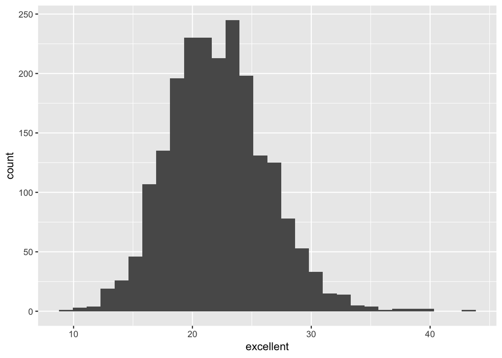

```r
ggplot(subset(brfss_smart2010, year = "2002"), aes(x = excellent)) + geom_histogram()
```